# Databike: coding an app about scooter upkeep

Sean Maden

4/9/2020

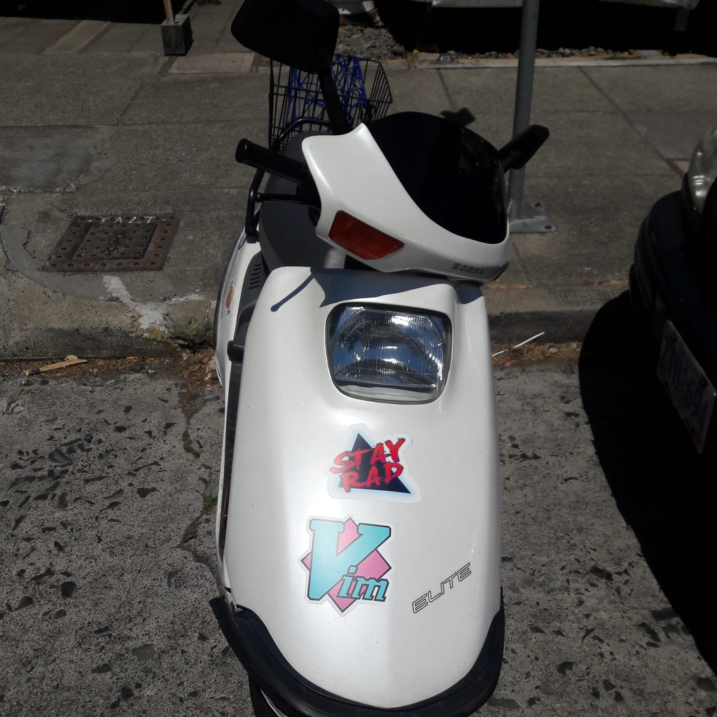

I’ve owned my 1987 CH150 Honda elite (a.k.a. “the databike”) for almost 2 years, but I’m still a novice when it comes to scooter repair and upkeep. My hobby inspired me to write an app about scooter upkeep. In this post, I describe early development on [`databike`](https://github.com/metamaden/databike/) using R, an app about scooter upkeep. In `databike`, the user makes decisions about maintenance (e.g. repair, maintain, or do nothing) and during obstacles encountered on rides (e.g. whether to quit or continue). These decisions impact the bike condition and total mileage or ride distance. The basic “user interface” consists of graphics (text/ascii art, printed in sequence), and user dialogues and notifications (pop-up windows with text and options buttons). The app code is available on GitHub ([link](https://github.com/metamaden/databike/)). This undertaking was novel for me, and I have loads of updates in mind.

# The application

With R installed, the app may be run from command line by navigating to the root directory (e.g. `cd /Documents/GitHub/databike`) and using:

```
R
source(app.R)
```

## Programming in R

[figure not shown]

Creating this app in R was a conscious design decision to test my programming knowledge. Rest assured, there are better languages and utilities more commonly used and supported for app development (e.g. developer kits, C++, Java, etc.). While the challenge of writing app code in R proved to be worthwhile, I also want to port the app to Python (see goals below). More generally, challenges of this kind already drive development of utilities that extend user capabilities to tackle real-world issues in data science and beyond.

## R scripts

Currently, the main app leans on 3 key scripts: `app.R`, `functions.R`, and `params.R`. These work together to define and update session variables, and manage user interfacing.

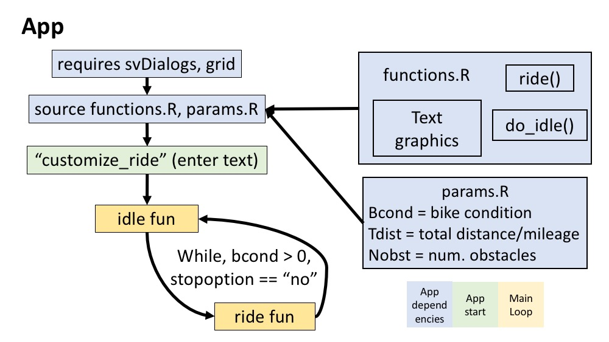

# User interfacing and dependencies

I asked 2 key questions about app usability: 1. Do looped graph prints create a pleasing animation or graphic? 2. Are dialogue trees feasible? Exploring these questions was a challenge unto itself, and my current solution requires 2 dependencies, [`svDialogs`](https://cran.r-project.org/web/packages/svDialogs/index.html) and [`grid`](https://bookdown.org/rdpeng/RProgDA/the-grid-package.html).

## Ascii art and “animations”

The game “graphics” are plotted characters printed at intervals, where animation intervals correspond to distance or mileage. The following example script illustrates the concept:

```
require(grid) # dependency
sleepint = 0.5 # pause between frame prints
# frame vector, or "slides" of animation
fv <- c(frame1, frame2, frame3)
ride.seq <- seq(1, 20, 1)
tdist <- 0
for(c in ride.seq){
  for(f in fv){
    grid.newpage()
    grid.text(f) # prints frame text
    Sys.sleep(sleepint)
  }
  tdist <- tdist + 1
}
```

The for loop iterates on c (unit distance) once per animation loop, where total distance is the maximum entry in ride.seq. The animation loop prints frames in the frame vector fv using `grid.newpage()` and `grid.text()`, and framerate is controlled by sleepint in `Sys.sleep(sleepint)`.

## Obstacles during rides

Obstacles are randomly encountered on rides, triggering a continue/quit prompt. This is managed by `o.seq`, a vector of numbers matching entries in `ride.seq`. The total obstacles in is randomized num.obst using `sample()`. In terms of the above example script, this adds 2 variables and a nested if/else condition:

```
require(grid) # dependency
sleepint = 0.5 # pause between frame prints
# frame vector, or "slides" of animation
fv <- c(bike.frame1, bike.frame2, bike.frame3)
ride.seq <- seq(1, 20, 1)
tdist <- 0
# obstacles data
num.obst <- sample(10, 1) # obstacle quantity
o.seq <- sample(ride.seq, num.obst) # obstacle indices
for(c in ride.dist){
  if(c in o.seq){
    # handles obstacle encounter
  } else{
    for(f in fv){
    grid.newpage()
    grid.text(f) # prints frame text
    Sys.sleep(sleepint)
  }
  tdist <- tdist + 1
  }
}
```

Where `#handles obstacle encounter` manages options for the obstacle encounter, with a chance to update bike condition (`bcond` variable) or stop the ride sequence altogether.

# Further goals

There are several improvements that would greatly increase this app’s usability, and their pursuit could lead to new insights. These include:

1. Scheduled error report logs and automated game tests (run app iterations and log outcomes or new errors)
2. Window management (e.g. manage multiple windows)
3. Python port
4. Save/load ride (use caching, use menu for load option)
5. Work on the real databike ;)

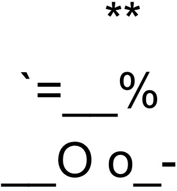